# A Tufte Handout Example

An implementation in R Markdown

JJ Allaire and Yihui Xie

2024-12-24

# Introduction

There are times when we want to compare time-to-failure data from two or more groups. For example, a designer might want to implement a new design to reduce costs, but wants to make sure that this change does not adversely affect the reliability of the product. Or, a manufacturer might want to find out if there is any difference in the time-to-failure of products manufactured from different batches or different assembly lines. Hypothesis testing can be used to compare such data.

Two of my previous blog articles([**here**](https://rpubs.com/shishir909/1199328) and [**here**](https://rpubs.com/shishir909/1226309)) dealt with non-parametric methods for comparing failure data. In this article, I demonstrate the use of a parametric method for the same purpose.

# Data

The data used in this article is from the book Statistical Methods for Reliability Data, Second Edition (William Q. Meeker, Luis A. Escobar, Francis G. Pascual)]. Table 1 shows this data, and it is also publicly available on DataShare, Iowa State University’s open data repository which can be accessed through **this link**.

The values in Table 1 are the results of a pull test to measure the bond strength of wire bonds from three separate manufacturing batches. We are interested in finding out whether there are statistically significant differences in the distribution of bond strength across the different manufacturing batches. If we do find that there is a statistically significant differnce, we want to find out whre is this difference (between which pairs of batches).

Table 1. Bond Strength

| Batch Number | Strength (g) | Censoring Indicator |
| --- | --- | --- |
| Batch1 | 504 | Failed |
| Batch1 | 168 | Failed |
| Batch1 | 420 | Failed |
| Batch1 | 336 | Failed |
| Batch1 | 540 | Failed |
| Batch1 | 516 | Failed |
| Batch1 | 936 | Failed |
| Batch1 | 756 | Failed |
| Batch1 | 936 | Failed |
| Batch1 | 592 | Failed |
| Batch1 | 468 | Failed |
| Batch1 | 600 | Censored |
| Batch1 | 376 | Failed |
| Batch1 | 600 | Censored |
| Batch1 | 600 | Censored |
| Batch1 | 588 | Failed |
| Batch1 | 600 | Censored |
| Batch1 | 600 | Censored |
| Batch4 | 396 | Failed |
| Batch4 | 300 | Failed |
| Batch4 | 420 | Failed |
| Batch4 | 336 | Failed |
| Batch4 | 516 | Failed |
| Batch4 | 540 | Failed |
| Batch4 | 396 | Failed |
| Batch4 | 696 | Failed |
| Batch4 | 600 | Failed |
| Batch5 | 516 | Failed |
| Batch5 | 300 | Failed |
| Batch5 | 420 | Failed |
| Batch5 | 540 | Failed |
| Batch5 | 276 | Failed |
| Batch5 | 276 | Failed |

# Analysis with Separate Distributions

In order to proceed with a parametric comparison of the different groups, we first need to figure out which parametric distribution to use for the data. Weibull and log-normal are the most commonly used distributions to describe time-to-failure in reliability applications. For the purpose of demonstrating a parametric comparison, we will consider these two distributions. We have three groups in our dataset: Batch 1, Batch 4 and Batch 5. Generally, when the failure mode is the same in all groups, the same distribution is used to fit the data.

Figure 1 shows a Weibull probability plot and Figure 2 shows a log normal probability plot of the data. The points on these plots are the empirical CDF and the lines are ML estimates from fitting the respective distributions.

Cumulative Distribution Function

Maximum likelihood

Figure 1: Weibull Probability Plot

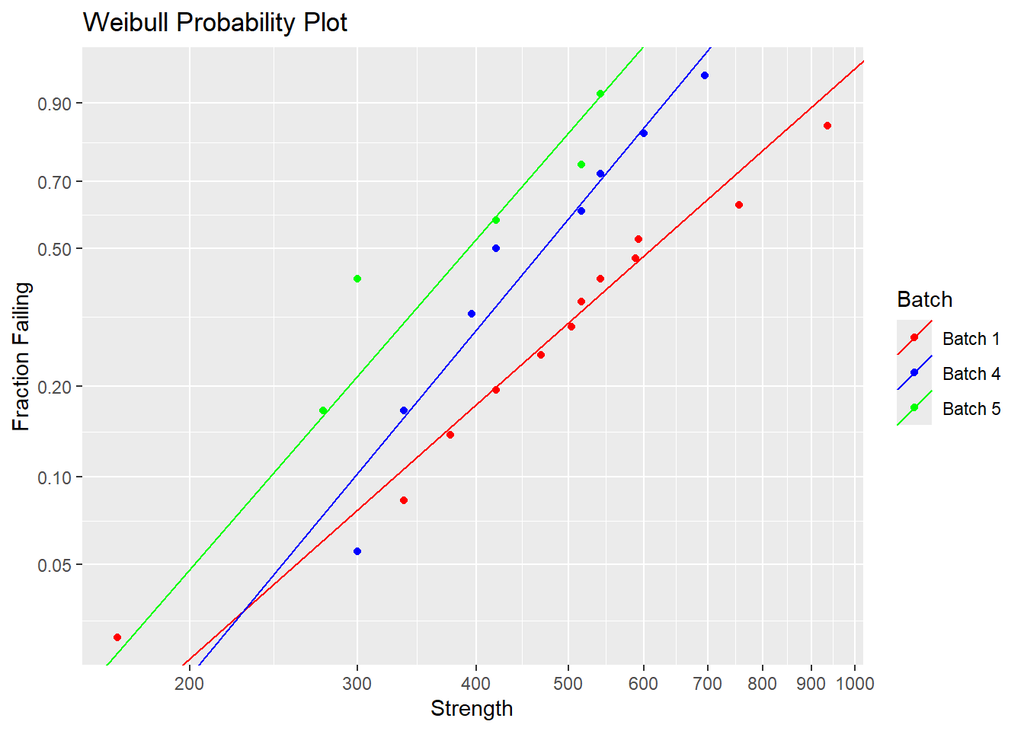

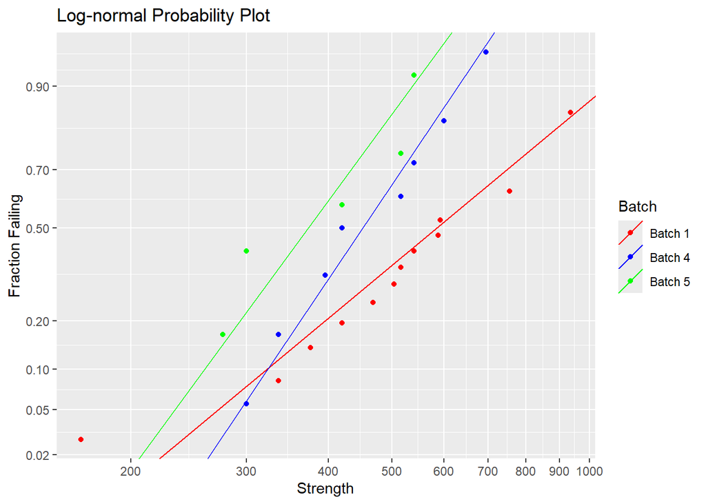

```r
#Log Normal

#Points - Same as above

#Lines

fit_2.Batch1.logNormal <- survival::survreg(Surv(Strength, delta) ~ 1, data = batch1_df, dist = "lognormal")

fit_2.Batch4.logNormal <- survival::survreg(Surv(Strength, delta) ~ 1, data = batch4_df, dist = "lognormal")

fit_2.Batch5.logNormal <- survival::survreg(Surv(Strength, delta) ~ 1, data = batch5_df, dist = "lognormal")

mu.ML_Batch1.logNormal <- fit_2.Batch1.logNormal$coefficients
se_mu.ML_Batch1logNormal <- sqrt(fit_2.Batch1.logNormal[["var"]][1,1])
sigma.ML_Batch1.logNormal <- fit_2.Batch1.logNormal$scale
se_sigma.ML_Batch1.logNormal <- sqrt((sigma.ML_Batch1.logNormal**2)*fit_2.Batch1.logNormal[["var"]][2,2])

mu.ML_Batch4.logNormal <- fit_2.Batch4.logNormal$coefficients
se_mu.ML_Batch4logNormal <- sqrt(fit_2.Batch4.logNormal[["var"]][1,1])
sigma.ML_Batch4.logNormal <- fit_2.Batch4.logNormal$scale
se_sigma.ML_Batch4.logNormal <- sqrt((sigma.ML_Batch4.logNormal**2)*fit_2.Batch4.logNormal[["var"]][2,2])

mu.ML_Batch5.logNormal <- fit_2.Batch5.logNormal$coefficients
se_mu.ML_Batch5logNormal <- sqrt(fit_2.Batch5.logNormal[["var"]][1,1])
sigma.ML_Batch5.logNormal <- fit_2.Batch5.logNormal$scale
se_sigma.ML_Batch5.logNormal <- sqrt((sigma.ML_Batch5.logNormal**2)*fit_2.Batch5.logNormal[["var"]][2,2])

#Transformers

xTransformer.logNormal <- scales::trans_new(
  name = "logNormal.x.transform",
  transform = function(t.p){
    x = log(t.p)
    return(x)
  },
  inverse = function(x) {
    t.p = exp(x)
    return(t.p)
  }
)


yTransfomer.logNormal <- scales::trans_new(
  name = "logNormal.y.transform",
  transform = function(p){
    y = qnorm(p)
    return(y)
  },
  inverse = function(y) {
    p = pnorm(y)
    return(p)
  }
)

cols <- c("Batch 1"="red","Batch 4"="blue","Batch 5"="green")

ggplot() + geom_point(data = CDF_Batch1.df, aes(x = Strength, y = p, col = "Batch 1")) + geom_abline(
  aes(intercept = (-mu.ML_Batch1.logNormal/sigma.ML_Batch1.logNormal), #y-axis intercept
      slope = 1/sigma.ML_Batch1.logNormal,
      col = "Batch 1"
)) + geom_point(data = CDF_Batch4.df, aes(x = Strength, y = p, col = "Batch 4")) + geom_abline(
  aes(intercept = (-mu.ML_Batch4.logNormal/sigma.ML_Batch4.logNormal), #y-axis intercept
      slope = 1/sigma.ML_Batch4.logNormal,
      col = "Batch 4"
)) + geom_point(data = CDF_Batch5.df, aes(x = Strength, y = p, col = "Batch 5")) + geom_abline(
  aes(intercept = (-mu.ML_Batch5.logNormal/sigma.ML_Batch5.logNormal), #y-axis intercept
      slope = 1/sigma.ML_Batch5.logNormal,
      col = "Batch 5"
)) + scale_x_continuous(
  transform = xTransformer.logNormal,
  name = "Strength",
  breaks = c(5, 10, 20, 50, 100, 200,300,400,500,600,700,800,900,1000)
) + scale_y_continuous(
  transform = yTransfomer.logNormal,
  name = "Fraction Failing",
  breaks = c(0.00003,0.0001,0.0002,0.0005,0.001,0.003,0.01,0.02,0.05,0.1,0.2,0.5,0.7,0.9)
) + ggtitle(label = "Log-normal Probability Plot") + scale_color_manual(name =
                                                                       "Batch", values = cols)
```

Note that 3 **separate** Weibull distributions were fit - one for each batch. Similarly, 3 **separate** log normal distributions were also fit. Looking at both plots above, the Weibull distribution seems to fit slightly better than the log-normal, but not by much. The data could have come from any of the two distributions we have considered here. Like I mentioned in my previous article on [**parametric regression**](https://rpubs.com/shishir909/1251052), we are mainly looking for any indication that a particular distribution is *definitely* not a good fit rather than *proving* that the data is from a particular distribution. The AIC from the Weibull model is 381.2918853 and the log-normal model is 382.2946935. Since the AIC is lower for the Weibull model, we will continue with Weibull distribution, although log-normal wouldn’t have been a terrible choice either.

Table 2 shows the location ($\mu$) and scale ($\sigma$) parameters from the log-location scale representation of the Weibull distribution.

Figure 3 shows the approximate 90% joint confidence regions based on the relative likelihood for the Weibull distribution median and the shape parameter $\beta$. The large amount of overlap between the Batch 4 and Batch 5 regions indicates that we do not have sufficient evidence at the 10% significance level to suggest that Batches 4 and 5 have different failure time distributions. The amount of overlap for Batch 1 with the other two batches is relatively smaller, but the presence of even some overlap suggests that the difference in distributions is not statistically significant at the 10% significance level.

# Analysis with Equal Shape parameter

| Batch | Parameter | ML Estimate | Standard Error | Wald Lower 90% CI | Wald Upper 90% CI |
| --- | --- | --- | --- | --- | --- |
| Batch 1 | $\hat{\mu}$ | 6.536 | 0.092 | 6.385 | 6.687 |
|  | $\hat{\sigma}$ | 0.331 | 0.071 | 0.306 | 0.357 |
| Batch 4 | $\hat{\mu}$ | 6.243 | 0.086 | 6.101 | 6.384 |
|  | $\hat{\sigma}$ | 0.243 | 0.062 | 0.218 | 0.270 |
| Batch 5 | $\hat{\mu}$ | 6.064 | 0.110 | 5.883 | 6.245 |
|  | $\hat{\sigma}$ | 0.254 | 0.083 | 0.214 | 0.303 |

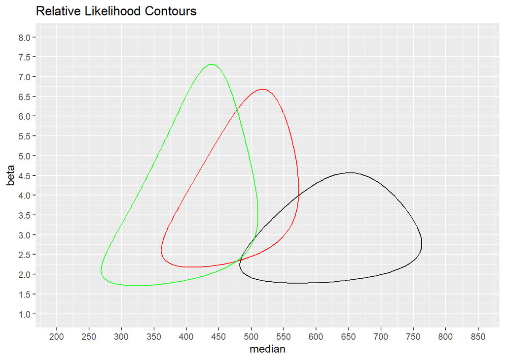

##End for now

# ROUGH

Checking if bond strength is a good dataset for the blog.

Plot weibull and log normal plots, with separate distributions for each batch.

Weibull looks a better fit

Compare AIC

Again, Weibull looks like a better fit. But note that Weibull is better only for batch 1. For batches 4 and 5, log normal appears a better fit.

Continue with Weibull fit since batch 1 has the highest number of failures.

Next, build an EqualSig models and conduct an LR test with SepDist model.

No reason to believe that sigma is different, but there is reason to believe that location parameter is different.

Now, construct simultaneous hypothesis test by constructing CI for the difference in median - for the SepDists and EqualSig model.

Only the pairwise comparison of Batch 1 vs Batch 5 does not contain 0. So, from the data, I can only say that there is evidence that Batch 1 is different to Batch 5. That is it.

Now, do the same comparison for the EqualSig model.

Here, there is evidence that Batch1 vs Batch4 are different, Batch1 vs Batch5 are different, but there is no evidence that Batch4 and Batch5 are different.